# Tugas 2 MPDW

Arfiah Kania Sektiaruni

2023-09-05

## Pemanggilan *Packages*

```r
library(dplyr)
library(TTR)
library(forecast)
library(lmtest) #digunakan untuk uji formal pendeteksian autokorelasi
library(orcutt) #untuk membuat model regresi Cochrane-Orcutt
library(HoRM) #untuk membuat model regresi Hildreth-Lu
```

```r
library(graphics)
library(TSA)
library(ggplot2)
library(RColorBrewer)
library(scales)
```

## Input Data

Data yang digunakan dalam kesempatan kali ini adalah data per 5 menit dari Bajaj Finance Stock Price periode 29 November - 30 November 2016.

```r
library(rio)
databajaj <- import("https://raw.githubusercontent.com/afhkaniase/praktikum-mpdw/main/Data/Data%20Latihan%202.csv")
databajaj
```

```
##      close   high    low
## 1   897.45 897.90 883.90
## 2   903.50 905.20 895.65
## 3   906.70 907.90 901.95
## 4   908.00 910.00 906.00
## 5   911.95 912.50 907.35
## 6   914.90 915.60 910.00
## 7   915.90 917.70 914.40
## 8   916.50 917.05 911.15
## 9   915.75 917.50 914.95
## 10  912.35 915.75 912.00
## 11  908.90 913.60 907.00
## 12  909.90 910.00 906.00
## 13  911.00 912.95 909.40
## 14  910.45 912.00 909.10
```

[output cut: 94 more lines]

```r
summary(databajaj)
```

```
##      close            high            low
##  Min.   :897.5   Min.   :897.9   Min.   :883.9
##  1st Qu.:913.8   1st Qu.:915.6   1st Qu.:911.1
##  Median :917.9   Median :919.0   Median :916.1
##  Mean   :916.1   Mean   :917.6   Mean   :914.3
##  3rd Qu.:919.0   3rd Qu.:920.6   3rd Qu.:918.0
##  Max.   :924.6   Max.   :927.9   Max.   :922.2
```

## Eksplorasi Data

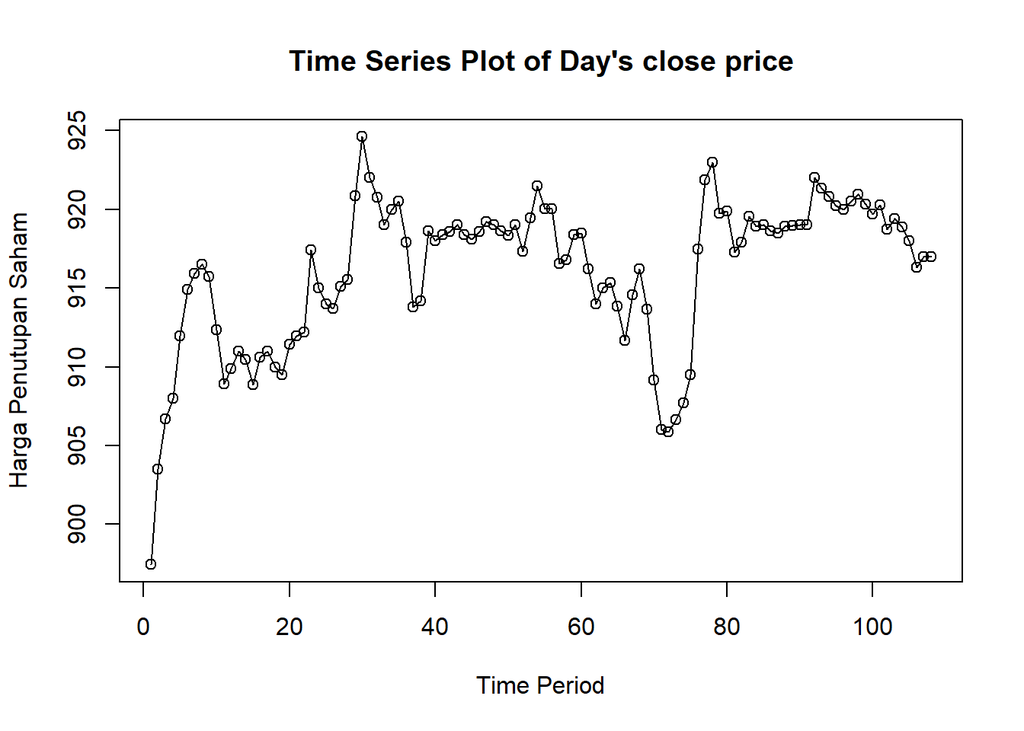

```r
#Membentuk objek time series
databajaj.ts <- ts(databajaj$close)

#Membuat plot time series
ts.plot(databajaj.ts, xlab = "Time Period",
        ylab = "Harga Penutupan Saham",
        main = "Time Series Plot of Day's close price")
points(databajaj.ts)
```

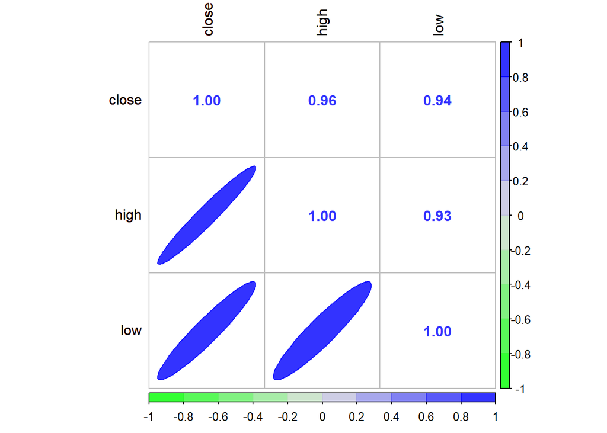

```r
# Membuat matriks korelasi
library(corrplot)
b <- cor(databajaj)

colors <- alpha(colorRampPalette(c("green", #Warna Bawah
                                   "#dbdbdb", #Warna Tengah
                                   "blue"))(10), #Warna Atas
                                   alpha = 0.80) #Transparan

corrplot(b, method = 'ellipse', type='lower', order='original', col=colors)
corrplot(b, add=TRUE, method = 'number', type='upper', order='original',
         tl.pos = "lt",
         tl.col = "black", col=colors)
```

## Regresi

```r
#Pembuatan Model Regresi
#model regresi
modelbajaj<- lm(databajaj$close ~ databajaj$high + databajaj$low , data = databajaj)
summary(modelbajaj)
```

```
##
## Call:
## lm(formula = databajaj$close ~ databajaj$high + databajaj$low,
##     data = databajaj)
##
## Residuals:
##     Min      1Q  Median      3Q     Max
## -2.7604 -0.7557  0.2466  0.6708  2.5032
##
## Coefficients:
##                Estimate Std. Error t value Pr(>|t|)
## (Intercept)    74.72386   20.70487   3.609 0.000473 ***
## databajaj$high  0.63191    0.05899  10.712  < 2e-16 ***
## databajaj$low   0.28604    0.04973   5.752 8.79e-08 ***
## ---
## Signif. codes:  0 '***' 0.001 '**' 0.01 '*' 0.05 '.' 0.1 ' ' 1
##
## Residual standard error: 1.096 on 105 degrees of freedom
## Multiple R-squared:  0.9474, Adjusted R-squared:  0.9464
## F-statistic: 946.2 on 2 and 105 DF,  p-value: < 2.2e-16
```

Model yang dihasilkan adalah
$$y_i =
74.72386 + 0.63191X_1 + 0.28604X_2$$
. Berdasarkan ringkasan model dapat diketahui bahwa hasil uji F memiliki *p-value* < $\alpha$ (5%). Artinya, minimal terdapat satu variabel yang berpengaruh nyata terhadap model. Hasil uji-t parsial kedua parameter regresi, yaitu intersep dan koefisien regresi juga menunjukkan hal yang sama, yaitu memiliki *p-value* < $\alpha$ (5%) sehingga nyata dalam taraf 5%. Selanjutnya dapat dilihat juga nilai $R^2=0.9474$. Artinya, sebesar 94.74% keragaman data penutupan harga saham dari Bajaj Finance’s dapat dijelaskan oleh harga tinggi dan harga rendah saham Bajaj Finance’s. Hasil ini menunjukkan hasil yang bagus, seolah mendapatkan hasil terbaik. Namun, kita perlu melakukan uji terhadap sisaannya seperti berikut ini.

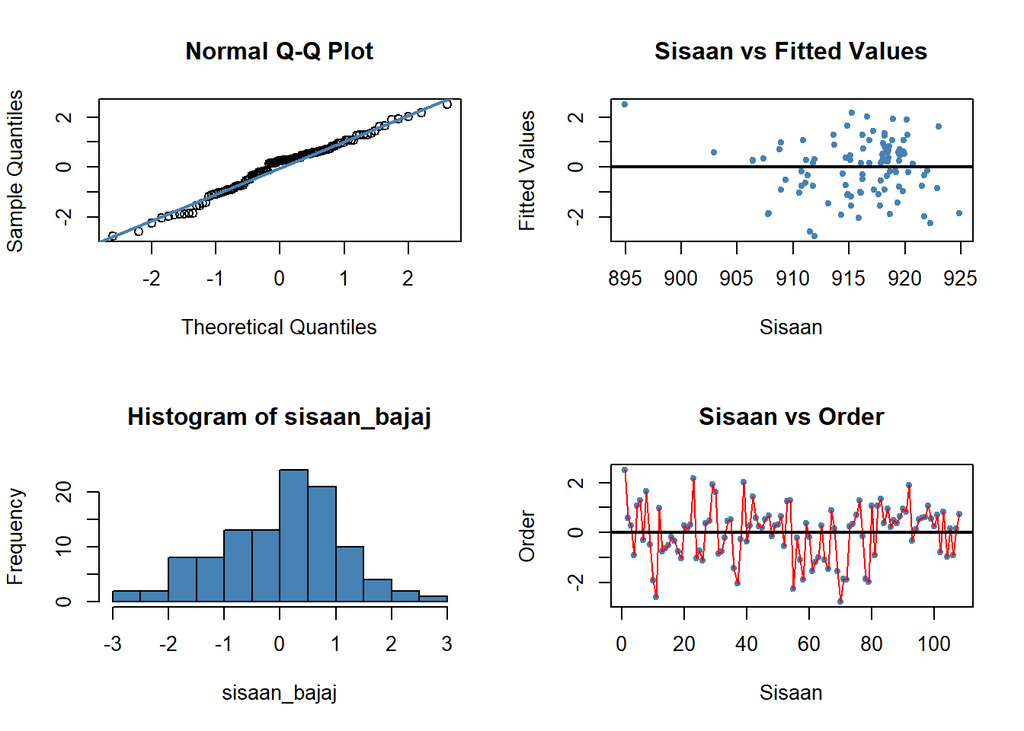

```r
#sisaan dan fitted value
sisaan_bajaj<- residuals(modelbajaj)
fitValue_bajaj<- predict(modelbajaj)

#Diagnostik dengan eksploratif
library(ggplot2)
par(mfrow = c(2,2))
qqnorm(sisaan_bajaj)

#Normal Q-Q plot
qqline(sisaan_bajaj, col = "steelblue", lwd = 2)
plot(fitValue_bajaj, sisaan_bajaj, col = "steelblue", pch = 20, xlab = "Sisaan", ylab = "Fitted Values", main = "Sisaan vs Fitted Values")
abline(a = 0, b = 0, lwd = 2)

#Histogram Sisaan
hist(sisaan_bajaj, col = "steelblue")
plot(seq(1,108,1), sisaan_bajaj, col = "steelblue", pch = 20, xlab = "Sisaan", ylab = "Order", main = "Sisaan vs Order")
lines(seq(1,108,1), sisaan_bajaj, col = "red")
abline(a = 0, b = 0, lwd = 2)
```

Dua plot di samping kiri digunakan untuk melihat apakah sisaan menyebar normal. Normal Q-Q Plot di atas menunjukkan bahwa sisaan cenderung menyebar normal, tetapi histogram dari sisaan tidak menunjukkan demikian. Selanjutnya, dua plot di samping kanan digunakan untuk melihat autokorelasi. Plot Sisaan vs *Fitted Value* dan Plot Sisaan vs *Order* menunjukkan adanya pola pada sisaan. Untuk lebih lanjut akan digunakan uji formal melihat normalitas sisaan dan plot ACF dan PACF untuk melihat apakah ada autokorelasi atau tidak.

```r
#Melihat Sisaan Menyebar Normal/Tidak
#H0: sisaan mengikuti sebaran normal
#H1: sisaan tidak mengikuti sebaran normal
ks.test(sisaan_bajaj, "pnorm", mean=mean(sisaan_bajaj), sd=sd(sisaan_bajaj))
```

```
##
##  Asymptotic one-sample Kolmogorov-Smirnov test
##
## data:  sisaan_bajaj
## D = 0.12566, p-value = 0.06602
## alternative hypothesis: two-sided
```

Berdasarkan uji formal Kolmogorov-Smirnov didapatkan nilai *p-value* > $\alpha$ (5%). Artinya, cukup bukti untuk menyatakan sisaan berdistribusi normal.

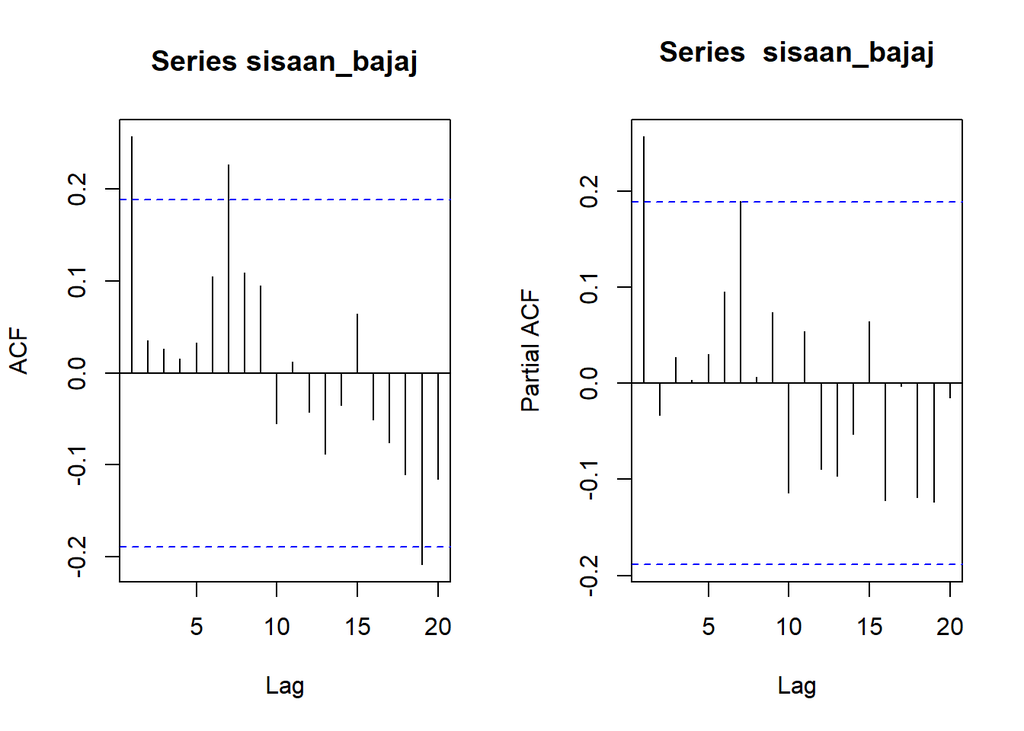

```r
#ACF dan PACF identifikasi autokorelasi
par(mfrow = c(1,2))
acf(sisaan_bajaj)
pacf(sisaan_bajaj)
```

Baik dari plot ACF maupun plot PACF, terdapat garis vertikal di lag tertentu yang melebihi tinggi garis biru horizontal. Artinya, menurut kedua plot ini, terdapat autokorelasi pada model. Namun, untuk lebih memastikan akan dilakukan uji formal dengan uji Durbin Watson.

### Durbin Watson

```r
#Deteksi autokorelasi dengan uji-Durbin Watson
#H0: tidak ada autokorelasi
#H1: ada autokorelasi
dwtest(modelbajaj)
```

```
##
##  Durbin-Watson test
##
## data:  modelbajaj
## DW = 1.4326, p-value = 0.0009011
## alternative hypothesis: true autocorrelation is greater than 0
```

Berdasarkan hasil DW Test, didapatkan nilai $DW = 1.4326$ dan *p-value* = $0.0009011$. Berdasarkan tabel Durbin-Watson diperoleh dengan $n = 108$ dan $k = 2$ sehingga nilai $DL = 1.6488$ dan $DU = 1.7241$. Nilai DW tidak berada di antara nilai DL dan DU. Artinya, berada di daerah di daerah autokorelasi positif. Namun, dengan nilai *p-value* < 0.05 dapat disimpulkan bahwa tolak H0, cukup bukti mengatakan adanya autokorelasi pada galat menurut uji Durbin-Watson.

### Breusch-Godfrey Test

```r
bgtest(databajaj$close ~ databajaj$high + databajaj$low, data=databajaj, order=1)
```

```
##
##  Breusch-Godfrey test for serial correlation of order up to 1
##
## data:  databajaj$close ~ databajaj$high + databajaj$low
## LM test = 7.808, df = 1, p-value = 0.005202
```

Dari hasil uji di atas, dapat terlihat bahwa nilai p-value < 0.05, sehingga tolak H0. Artinya, ada autokorelasi pada galat menurut uji Breusch-Godfrey.

### Runs Test

```r
lawstat::runs.test(resid(modelbajaj), alternative = 'two.sided')
```

```
##
##  Runs Test - Two sided
##
## data:  resid(modelbajaj)
## Standardized Runs Statistic = -1.5468, p-value = 0.1219
```

Dari hasil uji di atas, dapat terlihat bahwa nilai p-value > 0.05, sehingga terima H0. Artinya, tidak ada autokorelasi pada galat menurut uji Runs.

Dari ketiga uji di atas, masih terdapat dua uji yaitu uji Durbin-Watson dan Breusch-Godfrey Test yang menolak H0 atau menyatakan bahwa ada autokorelasi pada galat. Oleh karena itu, diperlukan penangan autokorelasi. Penanganan yang akan digunakan menggunakan dua metode, yaitu Cochrane-Orcutt dan Hildret-Lu.

## Penanganan Autokorelasi

### Metode Cochrane-Orcutt

```r
#Penanganan Autokorelasi Cochrane-Orcutt
modelbajajCO<-cochrane.orcutt(modelbajaj)
modelbajajCO
```

```
## Cochrane-orcutt estimation for first order autocorrelation
##
## Call:
## lm(formula = databajaj$close ~ databajaj$high + databajaj$low,
##     data = databajaj)
##
##  number of interaction: 7
##  rho 0.226793
##
## Durbin-Watson statistic
## (original):    1.43255 , p-value: 9.011e-04
## (transformed): 1.99129 , p-value: 4.367e-01
##
##  coefficients:
##    (Intercept) databajaj$high  databajaj$low
##      56.087043       0.602942       0.335450
```

```r
#Rho optimum
rho<- modelbajajCO$rho
rho
```

```
## [1] 0.2267926
```

Selanjutnya akan dilakukan transformasi secara manual dengan syntax berikut ini.

```r
#Transformasi Manual
X1.trans<- databajaj$high[-1]-databajaj$high[-108]*rho
X2.trans<- databajaj$low[-1]-databajaj$low[-108]*rho
Y.trans <- databajaj$close[-1]-databajaj$close[-108]*rho
modelbajajCOmanual<- lm(Y.trans~X1.trans + X2.trans)
summary(modelbajajCOmanual)
```

```
##
## Call:
## lm(formula = Y.trans ~ X1.trans + X2.trans)
##
## Residuals:
##     Min      1Q  Median      3Q     Max
## -2.4887 -0.8355  0.1902  0.5846  2.2944
##
## Coefficients:
##             Estimate Std. Error t value Pr(>|t|)
## (Intercept) 43.36692   20.23731   2.143   0.0345 *
## X1.trans     0.60294    0.06380   9.450 1.14e-15 ***
## X2.trans     0.33545    0.05921   5.665 1.32e-07 ***
## ---
## Signif. codes:  0 '***' 0.001 '**' 0.01 '*' 0.05 '.' 0.1 ' ' 1
##
## Residual standard error: 1.03 on 104 degrees of freedom
## Multiple R-squared:  0.9131, Adjusted R-squared:  0.9114
## F-statistic: 546.2 on 2 and 104 DF,  p-value: < 2.2e-16
```

```r
#Mencari Penduga Koefisien Regresi setelah Transformasi ke Persamaan Awal
b0bajaj_bintang <- modelbajajCOmanual$coefficients[1]

b0bajaj <- b0bajaj_bintang/(1-rho)
b0bajaj
```

```
## (Intercept)
##    56.08704
```

```r
b1bajaj <- modelbajajCOmanual$coefficients[2]
b1bajaj
```

```
##  X1.trans
## 0.6029419
```

```r
b2bajaj <- modelbajajCOmanual$coefficients[3]
b2bajaj
```

```
##  X2.trans
## 0.3354501
```

Hasil perhitungan koefisien regresi tersebut akan menghasilkan hasil yang sama dengan model yang dihasilkan menggunakan *packages*.

### Metode Hildreth-Lu

Penanganan kedua adalah menggunakan metode Hildreth-Lu. Metode ini akan mencari nilai SSE terkecil dan dapat dicari secara manual maupun menggunakan packages. Jika menggunakan packages, gunakan `library` *packages* `HORM`.

```r
#Penanganan Autokorelasi Hildreth lu
# Hildreth-Lu
hildreth.lu.func<- function(r, model){
  x1 <- model.matrix(modelbajaj)[,2]
  x2 <- model.matrix(modelbajaj)[,3]

  y <- model.response(model.frame(modelbajaj))
  n <- length(y)
  t <- 2:n

  y <- y[t]-r*y[t-1]
  x1 <- x1[t]-r*x1[t-1]
  x2 <- x2[t]-r*x2[t-1]

  return(lm(y~x1+x2))
}

#Pencariab rho yang meminimumkan SSE
r <- c(seq(0.1,0.9, by= 0.1))
tab <- data.frame("rho" = r, "SSE" = sapply(r, function(i){deviance(hildreth.lu.func(i, modelbajaj))}))
round(tab, 4)
```

```
##   rho      SSE
## 1 0.1 112.3500
## 2 0.2 110.4337
## 3 0.3 110.9912
## 4 0.4 113.8547
## 5 0.5 118.7091
## 6 0.6 125.0600
## 7 0.7 132.4460
## 8 0.8 141.1234
## 9 0.9 152.3890
```

Pertama-tama akan dicari di mana kira-kira $ρ$ yang menghasilkan SSE minimum. Pada hasil di atas terlihat $ρ$ minimum ketika 0.2. Namun, hasil tersebut masih kurang teliti sehingga akan dicari kembali $ρ$ yang lebih optimum dengan ketelitian yang lebih. Jika sebelumnya jarak antar $ρ$ yang dicari adalah 0.1, kali ini jarak antar $ρ$ adalah 0.001 dan dilakukan pada selang 0.2 sampai dengan 0.5.

```r
#Rho optimal di sekitar 0.4
rOpt <- seq(0.2,0.5, by= 0.001)
tabOpt <- data.frame("rho" = rOpt, "SSE" = sapply(rOpt, function(i){deviance(hildreth.lu.func(i, modelbajaj))}))
head(tabOpt[order(tabOpt$SSE),])
```

```
##      rho      SSE
## 28 0.227 110.3454
## 27 0.226 110.3455
## 29 0.228 110.3456
## 26 0.225 110.3458
## 30 0.229 110.3460
## 25 0.224 110.3464
```

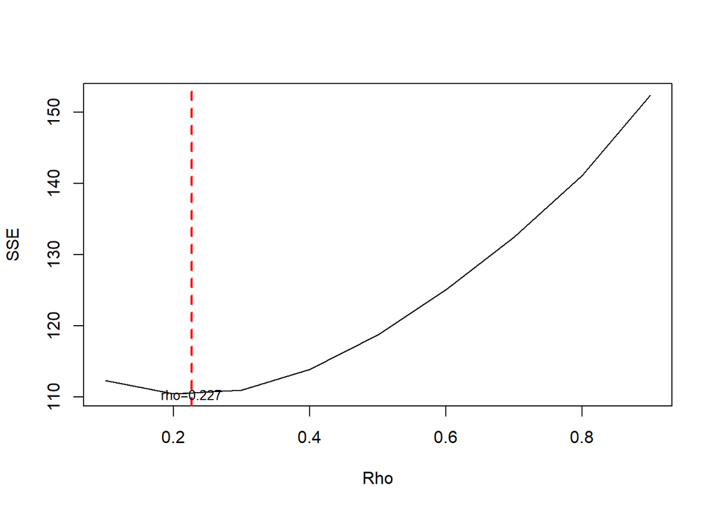

```r
#Grafik SSE optimum
par(mfrow = c(1,1))
plot(tab$SSE ~ tab$rho , type = "l", xlab = "Rho", ylab = "SSE")
abline(v = tabOpt[tabOpt$SSE==min(tabOpt$SSE),"rho"], lty = 2, col="red",lwd=2)
text(x=0.227, y=110.3454, labels = "rho=0.227", cex = 0.8)
```

Perhitungan yang dilakukan aplikasi `R` menunjukkan bahwa nilai $ρ$ optimum, yaitu saat SSE terkecil terdapat pada nilai $ρ=0.227$. Hal tersebut juga ditunjukkan pada plot. Selanjutnya, model dapat didapatkan dengan mengevaluasi nilai $ρ$ ke dalam fungsi `hildreth.lu.func`, serta dilanjutkan dengan pengujian autokorelasi dengan uji Durbin-Watson. Namun, setelah pengecekan tersebut tidak lupa koefisien regresi tersebut digunakan untuk transformasi balik. Persamaan hasil transformasi itulah yang menjadi persamaan sesungguhnya.

```r
#Model terbaik
modelbajajHL <- hildreth.lu.func(0.227, modelbajaj)
summary(modelbajajHL)
```

```
##
## Call:
## lm(formula = y ~ x1 + x2)
##
## Residuals:
##     Min      1Q  Median      3Q     Max
## -2.4890 -0.8357  0.1901  0.5847  2.2942
##
## Coefficients:
##             Estimate Std. Error t value Pr(>|t|)
## (Intercept) 43.35995   20.23672   2.143   0.0345 *
## x1           0.60296    0.06381   9.450 1.14e-15 ***
## x2           0.33542    0.05922   5.664 1.32e-07 ***
## ---
## Signif. codes:  0 '***' 0.001 '**' 0.01 '*' 0.05 '.' 0.1 ' ' 1
##
## Residual standard error: 1.03 on 104 degrees of freedom
## Multiple R-squared:  0.913,  Adjusted R-squared:  0.9114
## F-statistic: 545.9 on 2 and 104 DF,  p-value: < 2.2e-16
```

```r
#Transformasi Balik
cat("y = ", coef(modelbajajHL)[1]/(1-0.227), "+", coef(modelbajajHL)[2],"x1","+", coef(modelbajajHL)[3],"x2", sep = "")
```

```
## y = 56.09308+0.6029621x1+0.3354232x2
```

```r
#Deteksi autokorelasi
dwtest(modelbajajHL)
```

```
##
##  Durbin-Watson test
##
## data:  modelbajajHL
## DW = 1.9917, p-value = 0.4375
## alternative hypothesis: true autocorrelation is greater than 0
```

Hasil uji Durbin-Watson juga menunjukkan bawah nilai DW sebesar $1.9917$ berada pada selang daerah tidak ada autokorelasi, yaitu pada rentang DU < DW < 4-DU atau $1.7241 < DW < 2.2759$. Hal tersebut juga didukung oleh *p-value* sebesar $0.4375$, di mana *p-value* > $\alpha$=5%. Artinya tak tolak $H_0$ atau belum cukup bukti menyatakan bahwa ada autokorelasi dalam data nilai harga saham Bajaj Finance’s dengan metode Hildreth-Lu pada taraf nyata 5%.

Terakhir, akan dibandingkan nilai SSE dari ketiga metode (metode awal, metode Cochrane-Orcutt, dan Hildreth-Lu).

```r
#Perbandingan
sseModelbajajawal <- anova(modelbajaj)$`Sum Sq`[-c(1,2)]
sseModelbajajCO <- anova(modelbajajCOmanual)$`Sum Sq`[-c(1,2)]
sseModelbajajHL <- anova(modelbajajHL)$`Sum Sq`[-c(1,2)]
mseModelbajajawal <- sseModelbajajawal/length(databajaj$close)
mseModelbajajCO <- sseModelbajajCO/length(databajaj$close)
mseModelbajajHL <- sseModelbajajHL/length(databajaj$close)
akurasibajaj <- matrix(c(sseModelbajajawal,sseModelbajajCO,sseModelbajajHL,
                    mseModelbajajawal,mseModelbajajCO,mseModelbajajHL),nrow=2,ncol=3,byrow = TRUE)
colnames(akurasibajaj) <- c("Model Awal", "Model Cochrane-Orcutt", "Model Hildreth-Lu")
row.names(akurasibajaj) <- c("SSE","MSE")
akurasibajaj
```

```
##     Model Awal Model Cochrane-Orcutt Model Hildreth-Lu
## SSE 126.082954            110.345436        110.345441
## MSE   1.167435              1.021717          1.021717
```

Berdasarkan hasil tersebut dapat diketahui bahwa hasil penanganan autokorelasi dengan metode Cochrane-Orcutt dan Hildreth-Lu memiliki SSE yang sama, sebesar $110.3454$ dan lebih baik dibandingkan model awal ketika autokorelasi masih terjadi, yaitu sebesar $126.082954$.

# Simpulan

Autokorelasi yang terdapat pada data nilai harga saham Bajaj Finance’s terjadi akibat adanya korelasi di antara unsur penyusunnya. Adanya autokorelasi menyebabkan model regresi kurang baik karena akan meingkatkan galatnya. Autokorelasi dapat dideteksi secara eksploratif melalui plot sisaan, ACF, dan PACF, serta dengan uji formal Durbin-Watson. Namun, autokorelasi tersebut dapat ditangani dengan metode Cochrane-Orcutt dan Hildreth-Lu. Kedua metode menghasilkan nilai SSE yang sama, artinya keduanya baik untuk digunakan.